# Fundamentos de programación y análisis de datos en R

## Introducción

## R

*R* es un software para realizar computación estadística y visualización de datos (R Project); fue creado por *Ross Ihaka* y *Robert Gentleman* en 1991.

En el año 1995 es licenciado bajo GNU (*General Public License*) (Peng 2015) haciendo de este un software libre. Esto permitió acceder al código fuente posibilitando mejoras y a que la cantidad de usuarios aumentara, a tal punto de convertirse en uno de los programas más utilizados para realizar análisis de datos.

La filosofía de *R*, (Peng 2015), consiste en crear un entorno que permita realizar rutinas estadísticas complejas de manera sencilla mediante líneas de comando, adicionalmente, ofrecer un lenguaje para realizar programas en caso que las necesidades lo requieran.

## ¿Por qué utilizar R?

**R** es libre. Lo que implica que no hay que pagar por instalarlo, actualizarlo o compartilo. Además de lo anterior, algunos beneficios que valen la pena resaltar son:

- Tiene gran acogida en la comunidad científica y académica, por lo tanto, hay un gran número de personas dedicando su tiempo, esfuerzo y trabajo desarrollando en él.
- Aprender un software requiere esfuerzo y tiempo, por lo que conocer una herramienta que pueda ser utilizada en ambientes académicos, investigativos y empresariales.
- Una comunidad grande y sólida que brinda soporte y nuevos paquetes.

## Desventajas

- No tiene soporte técnico ni garantía. Esto se resuelve debido a que la comunidad es activa y está en crecimiento
- No es rápido y si el código esta mal escrito puede ser terriblemente lento.
- Los objetos son almacenados en memoria, por lo tanto el mayor objeto está dado por la *RAM* del computador.
- No hay garantía que las rutinas estadísticas que vienen con los paquetes sean correctas. De allí que se debe tener muy claro lo que se está haciendo para identificar inconsistencias.
- Los usuarios de *R* no son generalmente programadores, por esta razón muchas de las rutinas están enfocadas a los resultados y no a desarrollar un código claro y rápido.

## Ejemplos

## Manos a la obra

## Objetos

En *R* existen 5 objetos principales:

- Lógicos.
- Enteros.
- Numeric (números reales).
- Complejos.
- Caracteres.

Estos objetos son la base del programa. Se pueden operar y agrupar para crear estructuras de datos y rutinas cada vez más complejas.

En la consola escribir y luego dar *Enter* a cada una de las siguientes líneas.

```r
      TRUE  # Este objeto es lógico
## [1] TRUE
      FALSE
## [1] FALSE
      10L # Se crea el diez como un entero
## [1] 10
      3.1415 # Este es un objeto de tipo double
## [1] 3.1415
      5 + 2i # Número complejo
## [1] 5+2i
      "hola mundo" # Es un carácter
## [1] "hola mundo"
```

*Nota* En la consola interactuamos con R; ingresamos comandos y nos devuelve respuestas.

Adicionalmente, *R* posee algunas variables de uso común:

- **NaN** (Not a Number). Indica que se están realizando operaciones incorrectas.
- **NA** Not Available. Es lo que en estadística se conoce comúnmente como faltantes.
- **Inf** Representa el infinito.
- **NULL** Se utiliza para representar un lista de longitud cero.

```r
0/0
## [1] NaN
1000 / Inf
## [1] 0
Inf / Inf
## [1] NaN
```

## Operadores

Los operadores son símbolos que indican que “operación” debe llevarse a cabo.

### Operadores lógicos

| Operador | Descripción |
| --- | --- |
| & | Y lógico (La comparación se realiza a lo largo del objeto). |
| \| | Ó lógico (La comparación realiza a lo largo del objeto). |
| ! | Operador de negación. |

| Operador | Descripción |
| --- | --- |
| && | (La comparación se realiza al primer elemento) |
| \|\| | (La comparación se realiza al primer elemento) |
| xor() | Es igual a: !(x\|y). Excluye el or. |

Conjunción lógica Y

```r
 TRUE & TRUE
## [1] TRUE
 TRUE & FALSE
## [1] FALSE
 FALSE & TRUE
## [1] FALSE
 FALSE & FALSE
## [1] FALSE
```

Conjunción lógica O

```r
 TRUE | TRUE
## [1] TRUE
 TRUE | FALSE
## [1] TRUE
 FALSE | TRUE
## [1] TRUE
 FALSE | FALSE
## [1] FALSE
```

```r
!TRUE
## [1] FALSE
!FALSE
## [1] TRUE
!(TRUE & FALSE)
## [1] TRUE
```

Para cada uno de los siguientes ejercicios determine la respuesta de antemano, luego compruebe en *R* el resultado.

- \(\small{TRUE \, \& \, FALSE \, | \, FALSE}\)
- \(\small{FALSE \,|\, FALSE \,|\, TRUE}\)
- \(\small{TRUE \, \& \, TRUE \, \& \, !FALSE}\)
- \(\small{(TRUE \, | \, FALSE) \, \& \, (FALSE \, \& \, FALSE)}\)
- \(\small{!(TRUE \, \& \, !(FALSE \,| \,FALSE))}\)

### Operadores relacionales

| Operador | Símbolo |
| --- | --- |
| Igual a | == |
| Menor que | < |
| Mayor que | > |
| Menor o igual | \(\leq\) |
| Mayor o igual | \(\geq\) |
| Diferente | != |

Veamos algunos ejemplos:

```r
2 < 10
## [1] TRUE
2 > 8
## [1] FALSE
TRUE == FALSE
## [1] FALSE
TRUE == 1
## [1] TRUE
FALSE == 0
## [1] TRUE
2 > 0 & 4 < 5
## [1] TRUE
3 > 6 | 4 < 5
## [1] TRUE
!(3 > 6 | 4 < 5)
## [1] FALSE
```

Determine de antemano la respuesta de cada uno de los siguientes ejercicios, luego compruebe el resultado en *R*.

- \(\small{!(2 == 2 \, \& \, 3 >= 2)}\)
- \(\small{!(2 > 3 \, | -10 > 0)}\)
- \(\small{49/49 == 1}\)
- \(\small{0.1 == .3/3}\)
- \(\small{0.3 - 0.1 == 0.2}\)

### Operadores aritméticos

| Operador | Símbolo |
| --- | --- |
| Suma | + |
| Resta | - |
| Multiplicación | * |
| División | / |
| Potenciación | ^ |

| Operador | Símbolo |
| --- | --- |
| Módulo | %% |
| División entera | %/% |
| Multiplicación de matrices | %*% |
| Producto exterior | %o% |
| Producto Kronecker | %x% |

### Operadores de asignación

| Operador | Descripción |
| --- | --- |
| <-, = | Asignación a la izquierda |
| -> | Asignación a la derecha. |

Un operador que emplearemos frecuentemente es el *dos puntos*. Este nos permite crear secuencias.

```r
10:1
##  [1] 10  9  8  7  6  5  4  3  2  1
5:10
## [1]  5  6  7  8  9 10
```

## Precedencias

Las *Precedencias* indican el orden en que se ejecutan las operaciones aritméticas y lógicas, [link](https://www.nytimes.com/2019/08/02/science/math-equation-pedmas-bemdas-bedmas.html?smtyp=cur&smid=tw-nytimes). A continuación algunas de ellas numeradas de la más importante 1 a la menos 10.

1. Paréntesis
2. Potenciación
3. Dos puntos
4. Módulo
5. Multiplicación y división.
6. Suma y resta
7. Comparaciones
8. Negación (!)
9. Y lógico
10. Ó lógico

### Ejercicios

Evalúe las siguientes expresiones en *R*.

- \(\small{5 + 2 ^ 3 - 4 \cdot 8/2}\)
- \(\frac{1}{\frac{1}{21} + \frac{1}{25} + \frac{1}{18} + \frac{1}{30}}\)
- \(\small{9+1.796 \cdot \sqrt{0.291 \cdot (\frac{1}{14}+\frac{1}{11})}}\)
- \(\small{\frac{9 \cdot \frac{23-\pi^3}{4} + 2^4}{3}}\)
- \(\small{f_{(x)} = \frac{1}{\sigma \sqrt{2\pi}} e^{-\frac{(x - \mu)^2}{2\sigma^2}} \\ \mu = 3.5 \; y \; \sigma = 2.6 \rightarrow f_{(3)}, f_{(2.98)}}\)

Realizar el siguiente ejercicio: [Hit the Lottery](https://codeforces.com/problemset/problem/996/A)

## Funciones

## Introducción a las funciones

Las funciones son una clase particular de objetos. A estos objetos generalmente se les ingresa unos argumentos, aunque pueden no llevarlos, para que realicen unos procedimientos y retornes una respuesta. La sintaxis se ejemplifica a continuación.

*Nombre_Función(Arg1, Arg2, Arg3, …)*

Algunas funciones de uso común.

- *getwd()*: Permite identificar el directorio de trabajo. Esta es la carpta donde *R* busca y guarda los archivos, datos y programas por defecto.
- *setwd()*: Esta función se utiliza para cambiar el directorio de trabajo.
- *help()*: Accedemos a la documentación.
- *example()*: Imprime en la consola algunos ejemplos.

```r
  c(1, 10, 20)
## [1]  1 10 20
  1:5
## [1] 1 2 3 4 5
  example("mean")
##
## mean> x <- c(0:10, 50)
##
## mean> xm <- mean(x)
##
## mean> c(xm, mean(x, trim = 0.10))
## [1] 8.75 5.50
```

## Ejercicios.

Con las funciones *example()* y *help()* estudie los siguientes comandos:

1. sd()
2. mean()
3. length()
4. nrow()
5. ncol()
6. rep()
7. seq()
8. abs()
9. floor()
10. ceiling()

dnorm, pnorm, qnorm, rnorm.

## Gráficos en dos dimensiones.

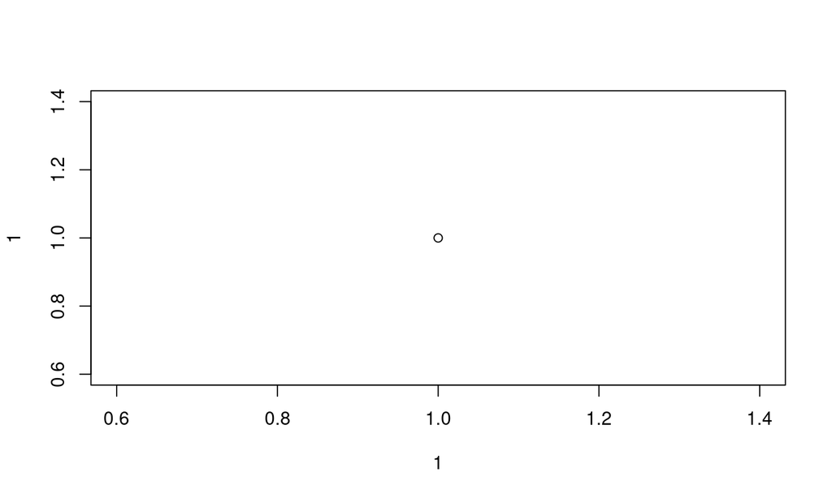

```r
plot(1, 1)
```

Esta función tiene una gran cantidad de parámetros. Recuerden que podemos acceder a la documentación con la función **help()**

### Grafiquemos una parábola.

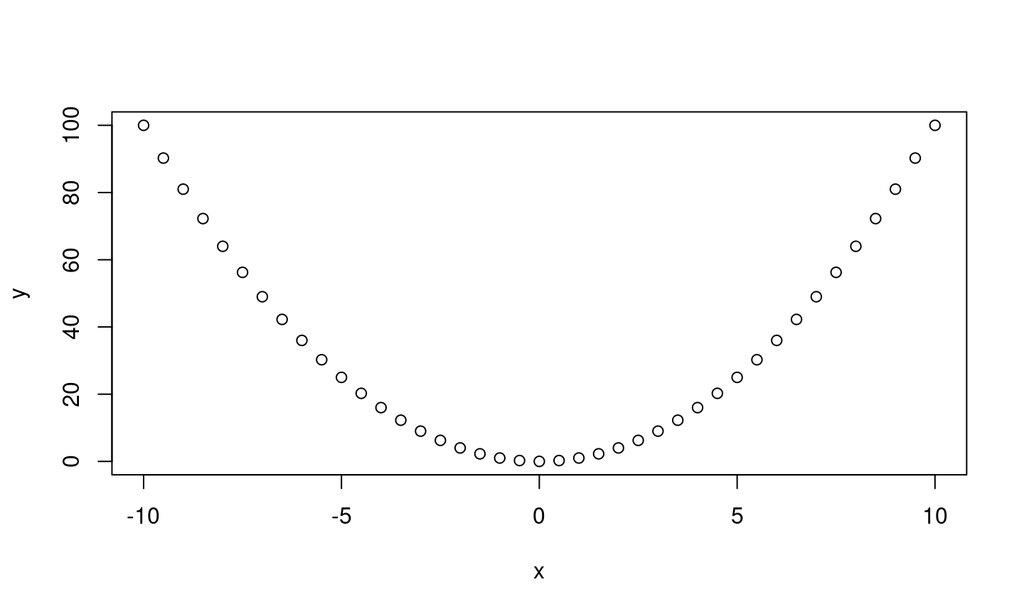

```r
x <- seq(-10, 10, by = 0.5)
y <- x ^ 2
plot(x, y)
```

\(O.o)/ Ahora unamos los puntos con una línea.

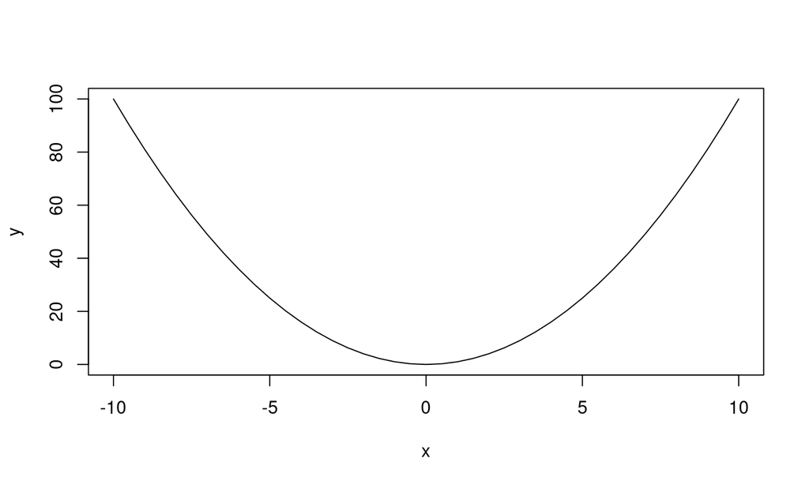

```r
x <- seq(-10, 10, by = 0.5)
y <- x ^ 2
plot(x, y, type = "l")
```

Modifiquemos el tipo de la línea, el espesor y el color.

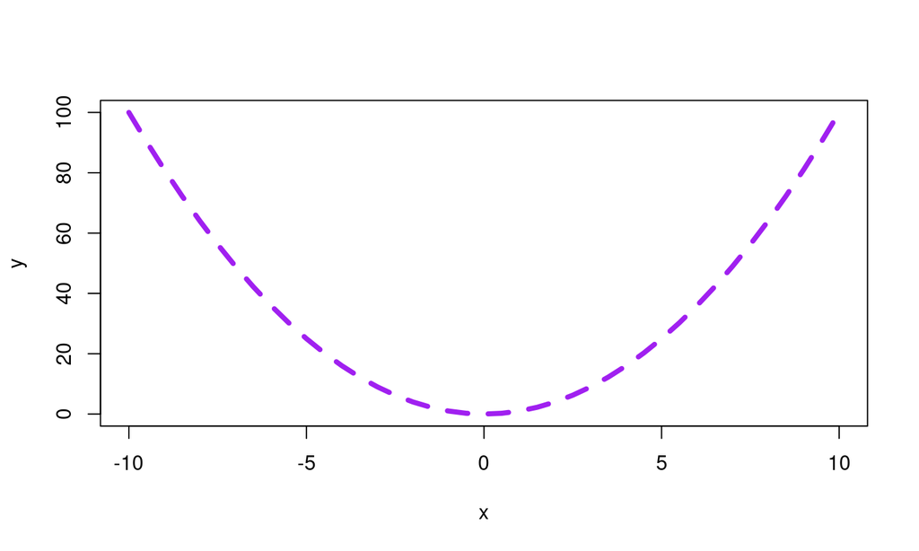

```r
x <- seq(-10, 10, by = 0.5)
y <- x ^ 2
plot(x, y, type = "l", lwd = 4, lty = 2, col = "purple")
```

Podemos poner el título al gráfico y a los ejes.

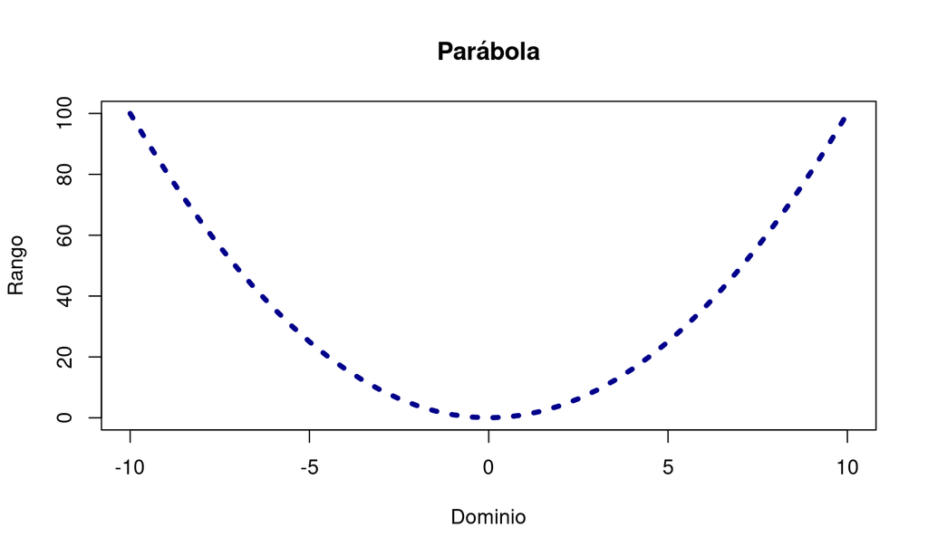

```r
x <- seq(-10, 10, by = 0.5)
y <- x ^ 2
plot(x, y, type = "l", lwd = 4, lty = 3, col = "darkblue",
     main = "Parábola", xlab = "Dominio", ylab = "Rango")
```

Una de las distribuciones de probabilidad más utilizadas en estadística es la [normal](https://mathworld.wolfram.com/NormalDistribution.html). Su expresión viene dada por:

\[ f(x) = \frac{1}{\sigma\sqrt{2 \pi}} e ^ {-\frac{(x-\mu)^2}{2\sigma^2}} \] Donde \(\mu\) representa el parámetro de posición y \(\sigma\) el de forma.

Vamos a realizar un plot de la gaussiana con las siguientes características:

1. \(\mu = 0, \mu = 2, \mu = -2\). y \(-10 \leq x \leq 10\).
2. Debe tener leyenda.
3. El eje y debe tener la función anterior.

Tips: [clic Me](https://stat.ethz.ch/R-manual/R-patched/library/grDevices/html/plotmath.html) y en la consola escriba: **demo(plotmath)**

El resultado debe ser similar al siguiente:

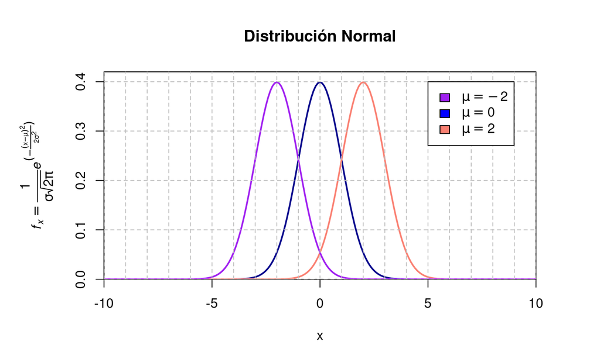

## Polígonos.

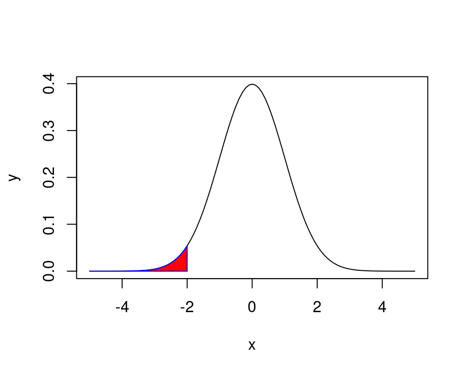

```r
x <- seq(-5, 5, 0.1); y <- dnorm(x, 0, 1)
plot(x, y, type = "l")
x_pol <- c(-5, -2, seq(-2, -5, -0.1))
y_pol <- c(0, 0, dnorm(seq(-2, -5, -0.1), 0, 1))
polygon(x_pol, y_pol, col = "red", border = "blue")
```

## Estructuras de datos

## Vectores

Los vectores en *R* son la estructura de datos básica. Se caracteriza porque todos los objetos deben ser del mismo tipo: lógicos, enteros, númericos, complejos o texto.

```r
 c(1, c(10, 20, 10), 5)
## [1]  1 10 20 10  5
 1:10
##  [1]  1  2  3  4  5  6  7  8  9 10
 seq(-2, -10, -1)
## [1]  -2  -3  -4  -5  -6  -7  -8  -9 -10
 rep(c(10, 20), times = 3)
## [1] 10 20 10 20 10 20
 rep(c(10, 20), each = 3)
## [1] 10 10 10 20 20 20
 rep(c(1, 3, 5), c(5, 2, 4))
##  [1] 1 1 1 1 1 3 3 5 5 5 5
```

Si se mezclan diferentes objetos en un mismo vector, *R* los convierte a un mismo tipo.

```r
c(TRUE, FALSE, "hola") # Todos texto
## [1] "TRUE"  "FALSE" "hola"
c(TRUE, FALSE, 3L) # Todos enteros
## [1] 1 0 3
c(5L, 4L, 2.5) # Todos double
## [1] 5.0 4.0 2.5
c(5, 5+2i) # Todos complejos.
## [1] 5+0i 5+2i
```

*Ejercicio:* Determine la jerarquía que utiliza *R* para convertir los objetos diferentes contenidos en un mismo vector.

*Sujerencia:* Cree un vector con todos los objetos y observe el resultado.

### Indexación de vectores.

La indexación es la forma como podemos acceder a los elementos de un vector. Para ello se utlizan los corchetes, **[]**, y la posición del elemento a seleccionar.

```r
x <- c(2, 3, 7, 11, 13, 17, 19, 23, 27)

x[1] # Accedo al elemento en la posición 1.
## [1] 2

x[9] # Accedo al elemento en la posición 9
## [1] 27

x[3:6] # Accedemos a los del 3 al 6.
## [1]  7 11 13 17

x[c(1, 4, 6, 9)] # Accedemos a los elementos 1, 4, 6 y  9.
## [1]  2 11 17 27
```

### Indexaciones lógicas de vectores

En este tipo de indexaciones los elementos son seleccionados si cumplen una condición.

```r
x <- c(-10, -5, 8, 12, 21, -17, 9)

x > 0 # Es TRUE donde los números son positivos.
## [1] FALSE FALSE  TRUE  TRUE  TRUE FALSE  TRUE

x[x>0] # Seleccinamos las posiciones donde ocurre el verdadero.
## [1]  8 12 21  9

x[x > 0 & x < 12] # Valores mayores a 0 y menores a 12.
## [1] 8 9

x[x < -5 | x > 12] # Valores menores a -5 y mayores a 12.
## [1] -10  21 -17
```

## Data frames.

Esta estructura permite almacenar la información de forma tabular. Cada columna debe ser del mismo tipo ya que representa una misma variable.

```r
set.seed(2)
datos <- data.frame(
  Inicial = letters[1:10], altura = rnorm(10, 160, 20),
  peso = rnorm(10, 60, 10), sexo = rbinom(10, 1, 0.5)
  )
head(datos)
##   Inicial   altura     peso sexo
## 1       a 142.0617 64.17651    1
## 2       b 163.6970 69.81753    0
## 3       c 191.7569 56.07305    0
## 4       d 137.3925 49.60331    0
## 5       e 158.3950 77.82229    1
## 6       f 162.6484 36.88931    1
```

### Indexación de data frames.

```r
datos$Inicial
##  [1] "a" "b" "c" "d" "e" "f" "g" "h" "i" "j"

datos[, 1]
##  [1] "a" "b" "c" "d" "e" "f" "g" "h" "i" "j"

datos[2, ]
##   Inicial  altura     peso sexo
## 2       b 163.697 69.81753    0

datos[3:6, ]
##   Inicial   altura     peso sexo
## 3       c 191.7569 56.07305    0
## 4       d 137.3925 49.60331    0
## 5       e 158.3950 77.82229    1
## 6       f 162.6484 36.88931    1
```

```r
datos[c(2, 5, 9), ]
##   Inicial   altura     peso sexo
## 2       b 163.6970 69.81753    0
## 5       e 158.3950 77.82229    1
## 9       i 199.6895 70.12829    1

datos[c(2, 5, 9), 2:3]
##     altura     peso
## 2 163.6970 69.81753
## 5 158.3950 77.82229
## 9 199.6895 70.12829

datos[c(2, 5, 9), c("Inicial", "sexo")]
##   Inicial sexo
## 2       b    0
## 5       e    1
## 9       i    1
```

```r
datos[1:5, c("Inicial", "sexo")]
##   Inicial sexo
## 1       a    1
## 2       b    0
## 3       c    0
## 4       d    0
## 5       e    1

datos$Inicial
##  [1] "a" "b" "c" "d" "e" "f" "g" "h" "i" "j"

datos$sexo
##  [1] 1 0 0 0 1 1 1 0 1 1

datos$sexo[1:5]
## [1] 1 0 0 0 1

datos$altura[c(1, 5, 10)]
## [1] 142.0617 158.3950 157.2243
```

### Indexación lógica con data frames

```r
datos[datos$peso >= 68, ]
##   Inicial   altura     peso sexo
## 2       b 163.6970 69.81753    0
## 5       e 158.3950 77.82229    1
## 7       g 174.1591 68.78605    1
## 9       i 199.6895 70.12829    1

datos[datos$sexo == 1, ]
##    Inicial   altura     peso sexo
## 1        a 142.0617 64.17651    1
## 5        e 158.3950 77.82229    1
## 6        f 162.6484 36.88931    1
## 7        g 174.1591 68.78605    1
## 9        i 199.6895 70.12829    1
## 10       j 157.2243 64.32265    1
```

```r
datos[datos$sexo == 1 & datos$altura <= 170, ]
##    Inicial   altura     peso sexo
## 1        a 142.0617 64.17651    1
## 5        e 158.3950 77.82229    1
## 6        f 162.6484 36.88931    1
## 10       j 157.2243 64.32265    1

datos[datos$sexo == 0 & datos$altura > 170, 2:3]
##     altura     peso
## 3 191.7569 56.07305

datos[datos$altura <= 165 & datos$peso >= 53, c("altura", "peso")]
##      altura     peso
## 1  142.0617 64.17651
## 2  163.6970 69.81753
## 5  158.3950 77.82229
## 8  155.2060 60.35807
## 10 157.2243 64.32265
```

## Ingresar datos

Leer información es una de las actividades que más se realizan durante el análisis de datos. Esta información puede venir en diferentes formatos como:

- Archivos separados por comas (.csv).
- Libros de Excel (.xlsx, .xlx).
- Se puede leer información de una página web.
- Archivos binarios
- Imágenes, audios y vídeos.

En general hay una gran cantidad de formatos.

Inicialmente vamos a leer los datos con la función *read.csv()*. Vamos a leer el archivo *cities.csv* que se encuentra en la carpeta: *‘’Datos/Fin_Semana_1/varios’’* del repositorio.

```r
ciudades <- read.csv("../Datos/Fin_Semana_1/varios/cities.csv")
head(ciudades[1:5], 10)
##              city     city_ascii     lat     lng    pop
## 1   Qal eh-ye Now      Qal eh-ye 34.9830 63.1333   2997
## 2     Chaghcharan    Chaghcharan 34.5167 65.2500  15000
## 3     Lashkar Gah    Lashkar Gah 31.5830 64.3600 201546
## 4          Zaranj         Zaranj 31.1120 61.8870  49851
## 5      Tarin Kowt     Tarin Kowt 32.6333 65.8667  10000
## 6    Zareh Sharan   Zareh Sharan 32.8500 68.4167  13737
## 7        Asadabad       Asadabad 34.8660 71.1500  48400
## 8         Taloqan        Taloqan 36.7300 69.5400  64256
## 9  Mahmud-E Eraqi Mahmud-E Eraqi 35.0167 69.3333   7407
## 10     Mehtar Lam     Mehtar Lam 34.6500 70.1667  17345
```

Luego de leer los datos realizar las siguientes actividades.

- Realizar un gráfico de dispersión de longitud vs latitud.
- En el gráfico anterior mostrar las ciudades con más de un millón de habitantes.
- Realizar un gráfico únicamente con las ciudades Colombinas.
- Realizar un gráfico con las ciudades de los siguientes países: Estados Unidos, Canadá, México, Colombia, Venezuela, Ecuador, Perú, Bolivia, Chile, Brasil, Argentina, Uruguay, Paraguay, Surinam y Trinidad y Tobago.
- Realizar un histograma con la variable población.
- Realizar un boxplot con la variable población.
- Leer el archivo: *cumple.csv* y probar la paradoja del cumpleaños.
- Leer el archivo: *datos_fumadores.csv* y realizar los siguientes gráficos: Un boxplot de edad vs Fumador, Presión vs Fumador y Riesgo vs Fumador.
- Realizar una prueba t-estudent para determinar si el fumar impacta el riesgo, presión y la edad.

## Referencias

Peng, Roger. 2015. *R Programming for Data Science*.

R Project. “The r Project for Statistical Computing.” https://www.r-project.org/.